# Quality control

GBM/OV/PDAC

## Verdict

Everything **Quality control** produced, summarised before any detail.

**How to read it.** Findings are computed from this stage’s own outputs at render time, ranked worst-first — they cannot disagree with the tables below.

**What to watch for.** **critical** blocks the run; **warning** is worth a look before trusting downstream results.

Tables

2

published

Figures

1

Findings

2

2 warning

⚠ warning

Entries

12

in qc_per_sample

Sample status

⚠GBM_DFCI1_CSF ⚠GBM_DFCI2_CSF ✓GBM_DFCI3 ✓GBM_DFCI4 ✓GBM_DFCI5 ✓GBM_MSK1 ✓GBM_MSK2 ✓OV_TCGA1 ⚠OV_TCGA2 ✓PDAC_01 ✓PDAC_02 ⚠PDAC_03

✓ 8 good · ⚠ 4 warning

**Warning**

**Two CSF samples have low library complexity**

Median genes below 900 in GBM_DFCI1_CSF and GBM_DFCI2_CSF.

**Warning**

**4 of 12 entries flagged**

From `status` in `qc_per_sample`.

## Results

Every table **Quality control** produced, searchable and downloadable.

**How to read it.** Use the dropdown to switch table. Filter any column from its header; the buttons export the filtered rows, not just the page.

**What to watch for.** Row counts far below expectation usually mean an upstream filter removed more than intended.

composition 84 rows x 3 cols

| sample | lineage | cells |
| --- | --- | --- |
| GBM_DFCI1_CSF | B_Plasma_Cells | 46 |
| GBM_DFCI2_CSF | B_Plasma_Cells | 29 |
| GBM_DFCI3 | B_Plasma_Cells | 61 |
| GBM_DFCI4 | B_Plasma_Cells | 59 |
| GBM_DFCI5 | B_Plasma_Cells | 69 |
| GBM_MSK1 | B_Plasma_Cells | 44 |
| GBM_MSK2 | B_Plasma_Cells | 57 |
| OV_TCGA1 | B_Plasma_Cells | 52 |
| OV_TCGA2 | B_Plasma_Cells | 58 |
| PDAC_01 | B_Plasma_Cells | 49 |

[output cut: 74 more lines]

qc_per_sample 12 rows x 9 cols

| sample | cohort | csf | n_cells | median_genes | median_umi | pct_mito | doublet_rate | status |
| --- | --- | --- | --- | --- | --- | --- | --- | --- |
| GBM_DFCI1_CSF | GBM | True | 1389 | 715 | 866 | 17.3 | 9 | warning |
| GBM_DFCI2_CSF | GBM | True | 848 | 543 | 2424 | 13.5 | 5.5 | warning |
| GBM_DFCI3 | GBM | False | 13860 | 1981 | 6023 | 11.8 | 2.2 | good |
| GBM_DFCI4 | GBM | False | 9007 | 2574 | 6727 | 2.9 | 4.6 | good |
| GBM_DFCI5 | GBM | False | 9081 | 2302 | 6324 | 5.3 | 4.9 | good |
| GBM_MSK1 | GBM | False | 7331 | 1753 | 7291 | 7.2 | 6.7 | good |
| GBM_MSK2 | GBM | False | 11285 | 2028 | 5778 | 4.1 | 5.2 | good |
| OV_TCGA1 | OV | False | 10998 | 2128 | 6345 | 4.8 | 4.1 | good |
| OV_TCGA2 | OV | False | 12439 | 2177 | 6519 | 5.9 | 8.2 | warning |
| PDAC_01 | PDAC | False | 12810 | 1925 | 6200 | 1.3 | 4.4 | good |

[output cut: 2 more lines]

## Explore

The stage’s main table, plotted interactively.

**How to read it.** Pick a metric; hover any bar for its value, the cohort median and the deviation from it. Filter by group to compare subsets.

**What to watch for.** Bars that sit far from the median are the same entries flagged as outliers above.

Metric

Entry

[interactive chart not shown]

## Figures

Figures published by **Quality control**.

**How to read it.** Select a figure from the dropdown. Each is also written as a vector PDF beside the PNG for direct use in a manuscript.

**What to watch for.** A figure missing here that you expected usually means its analysis block was skipped, not that it failed.

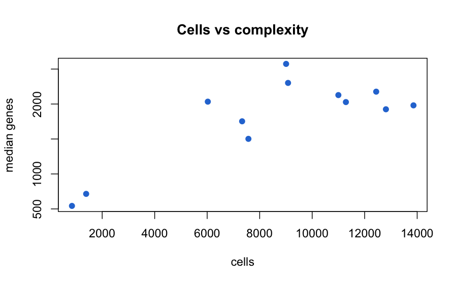

## Ask

A question box answering from this stage’s own data — no network needed.

**How to read it.** Ask in plain language: what failed, any rare patterns, top N by a metric, compare two entries, or details for one entry.

**What to watch for.** Every number is computed live from the embedded tables. If a local model is serving on this machine it phrases the answer; it never supplies the numbers.

## Provenance

**Files this report was built from**

**Tables (2)**

- `composition.csv`
- `qc_per_sample.csv`

**Figures (1)**

- `example_figure.png`

**Machine-readable findings**

```json
 [
  {
    "id": "stage_note",
    "severity": "warning",
    "headline": "Two CSF samples have low library complexity",
    "detail": "Median genes below 900 in GBM_DFCI1_CSF and GBM_DFCI2_CSF.",
    "stage": "qc",
    "value": null,
    "scope": ""
  },
  {
    "id": "stage_warn",
    "severity": "warning",
    "headline": "4 of 12 entries flagged",
    "detail": "From `status` in `qc_per_sample`.",
    "stage": "qc",
    "value": 4,
    "scope": ""
  }
]
```